# 📊 Estatística Descritiva com Python

A estatística descritiva tem como objetivo **organizar, resumir e descrever um conjunto de dados**.

Antes de construir modelos ou fazer análises mais complexas, precisamos entender os dados.

Ela ajuda a responder perguntas como:

🔎 Qual é o valor típico dos dados?  
📈 Como os dados estão distribuídos?  
⚠️ Existem valores extremos?  
🔗 Existe relação entre variáveis?

Nesta aula vamos aprender a:

1️⃣ Identificar tipos de variáveis  
2️⃣ Explorar um conjunto de dados  
3️⃣ Calcular estatísticas descritivas  
4️⃣ Visualizar dados

# 🧰 Importando bibliotecas

Preparando o ambiente

Vamos importar algumas bibliotecas usadas em análise de dados.

```python
import pandas as pd
import numpy as np
import matplotlib.pyplot as plt
import seaborn as sns

sns.set(style="whitegrid")
```

# ❤️ Criando um dataset de exemplo em saúde

Vamos trabalhar com um pequeno conjunto de dados simulando pacientes de uma clínica.

Variáveis disponíveis:

👤 idade  
⚧️ sexo  
🩺 número de consultas  
🧪 glicose  
❤️ pressão arterial

```python
dados = pd.DataFrame({
    "idade":[23,45,34,65,52,41,38,29,60,48],
    "sexo":["F","M","F","M","F","F","M","F","M","F"],
    "consultas":[2,5,3,6,4,3,2,1,5,4],
    "glicose":[92,140,110,150,135,105,99,88,160,120],
    "pressao":[110,140,130,150,145,135,120,118,160,142]
})

dados
```

|  | idade | sexo | consultas | glicose | pressao |
| --- | --- | --- | --- | --- | --- |
| 0 | 23 | F | 2 | 92 | 110 |
| 1 | 45 | M | 5 | 140 | 140 |
| 2 | 34 | F | 3 | 110 | 130 |
| 3 | 65 | M | 6 | 150 | 150 |
| 4 | 52 | F | 4 | 135 | 145 |
| 5 | 41 | F | 3 | 105 | 135 |
| 6 | 38 | M | 2 | 99 | 120 |
| 7 | 29 | F | 1 | 88 | 118 |
| 8 | 60 | M | 5 | 160 | 160 |
| 9 | 48 | F | 4 | 120 | 142 |

# 🧠 O que é uma variável

Variáveis são **características ou propriedades que podem ser observadas ou medidas** em um estudo.

Exemplos em saúde:

👤 idade do paciente  
⚧️ sexo  
🧪 nível de glicose  
🩺 número de consultas

Essas características podem variar entre indivíduos.

# 🧩 Tipos de variáveis

As variáveis podem ser classificadas em duas categorias principais.

**Variáveis qualitativas**

Representam categorias.

Exemplos:

⚧️ sexo  
🩺 tipo de exame

Podem ser:

🔹 Nominais → não possuem ordem  
🔹 Ordinais → possuem ordem

**Variáveis quantitativas**

Representam valores numéricos.

Podem ser:

🔢 Discretas → contagem  
📏 Contínuas → medidas

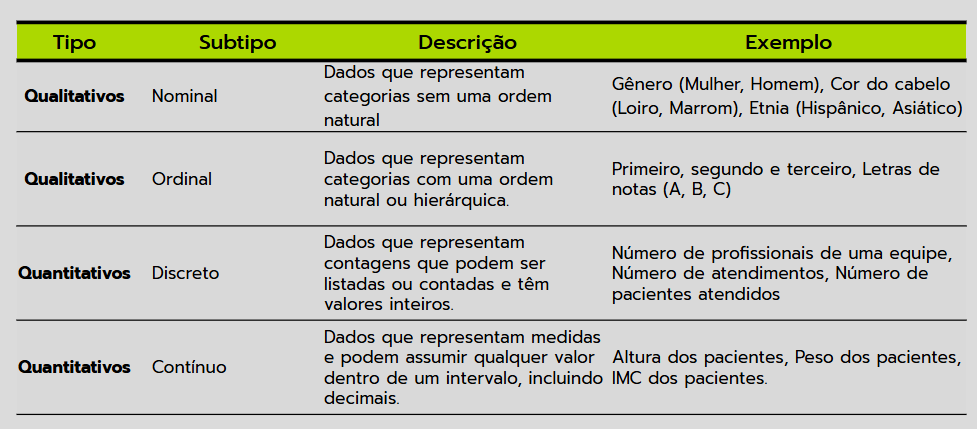

# 🔎 Estrutura do dataset

```python
dados.dtypes
```

|  | 0 |
| --- | --- |
| idade | int64 |
| sexo | object |
| consultas | int64 |
| glicose | int64 |
| pressao | int64 |

**dtype:** object

# 🧩 Por que categorizar as variáveis é importante?

Classificar corretamente as variáveis é uma etapa essencial em qualquer análise de dados.  
O tipo de variável influencia diretamente **como os dados serão tratados, analisados e interpretados**.

### 🧹 1️⃣ Preparação de dados

Saber o tipo de variável ajuda na **limpeza e preparação dos dados**, que são etapas críticas de qualquer análise.

Exemplos:

- tratar valores ausentes
- padronizar categorias
- converter tipos de dados

### 🔎 2️⃣ Escolha da análise apropriada

Cada tipo de variável exige **técnicas estatísticas diferentes**.

Por exemplo:

- variáveis categóricas → contagens e proporções
- variáveis numéricas → média, mediana, desvio padrão

### 📊 3️⃣ Visualização de dados

O tipo de variável também determina **qual gráfico utilizar**.

Exemplos:

- variável categórica → gráfico de barras
- variável contínua → histograma ou boxplot

### 🤖 4️⃣ Modelagem estatística e aprendizado de máquina

A escolha de modelos estatísticos ou algoritmos de machine learning depende do tipo de variável.

Exemplos:

- regressão linear → variável resposta contínua
- regressão logística → variável resposta categórica
- árvores de decisão → podem lidar com diferentes tipos de variáveis